CS F364: Design and Analysis of Algorithms

# Matrix Chain Multiplication

Lecture 11 |2026-06-04

# Matrix Chain Multiplication

- Matrix Chain Multiplication
- RNA Secondary Structure Prediction

## Recap: Dynamic Programming so far

**Lecture 10** introduced DP — two key ideas:

| Concept | Fibonacci | LCS |
| --- | --- | --- |
| Subproblems | $F_1,\dots,F_n$ | $C[i,j]$ for prefixes |
| Recurrence | $F_n = F_{n-1}+F_{n-2}$ | $C[i,j] = \dots$ from substrings |
| Table | 1D array | 2D matrix |
| Time | $O(n)$ | $O(mn)$ |

Both rely on **optimal substructure** and **overlapping subproblems** — we’ll see the same pattern in today’s new problems.

## Where does the name come from?

- In the 1950s, Richard Bellman was developing a theory for **multistage decision processes** at the RAND Corporation.
- The Secretary of Defense, **Charles Wilson**, had **“a pathological fear and hatred of the word, research”** — he would turn red and get violent if anyone used it in his presence.
- RAND was employed by the Air Force, which Wilson headed. Bellman needed a name that described **time-varying, multistage optimization** — but wouldn’t trigger Washington.

*“Thus, I thought dynamic programming was a good name. It was something not even a Congressman could object to. So I used it as an umbrella for my activities.”* — **Richard Bellman**, *Eye of the Hurricane* (1984)

## Matrix Multiplication Review

**Matrix:** An $p\times q$ array of numbers with $p$ rows and $q$ columns.

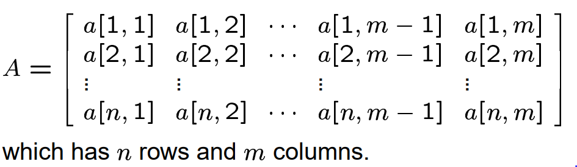

**Product:** $C = A_{p\times q} \times B_{q\times r}$ produces a $p\times r$ matrix where:
$$c[i,j] = \sum_{k=1}^{q} a[i,k]\cdot b[k,j]$$

**Cost:** Each of the $pr$ entries needs $\Theta(q)$ operations → **$\Theta(pqr)$ total**.

## Parenthesization Matters

Matrix multiplication is **associative**: $(AB)C = A(BC)$ — the result is the same regardless of grouping.

However, **the cost is not the same!**

$A(5\times4),\; B(4\times6),\; C(6\times2)$

- $(AB)C$: $(5\cdot4\cdot6) + (5\cdot6\cdot2) = 120 + 60 = \mathbf{180}$
- $A(BC)$: $(4\cdot6\cdot2) + (5\cdot4\cdot2) = 48 + 40 = \mathbf{88}$

**The cheaper order is $2\times$ faster!**

**Key observation:** Choosing the right parenthesization can drastically reduce computation cost.

## Matrix Chain Multiplication — Problem

**Given:** $n$ matrices $A_1,\dots,A_n$ with dimensions $p_{i-1}\times p_i$.

**Goal:** Find the parenthesization of $A_1A_2\cdots A_n$ that minimizes the number of scalar multiplications.

**Example:** $A_1(5\times4)$, $A_2(4\times6)$, $A_3(6\times2)$

- $(A_1A_2)A_3$: $5\cdot4\cdot6 + 5\cdot6\cdot2 = 120+60 = 180$
- $A_1(A_2A_3)$: $4\cdot6\cdot2 + 5\cdot4\cdot2 = 48+40 = 88$

**Key insight:** Parenthesization matters — costs can differ by $2\times$ or more!

## Why Exhaustive Search Fails

The number of distinct parenthesizations of $n$ matrices is the **Catalan number**:
$$C_{n-1} = \frac{1}{n}\binom{2n-2}{n-1}
\;\sim\;
\frac{4^{n-1}}{(n-1)^{3/2}\sqrt{\pi}}$$

**Recurrence:** $P(1)=1$, $P(n)=\sum_{k=1}^{n-1} P(k)\,P(n-k)$

**DP approach:** $O(n^3)$ — polynomial instead of exponential!

## DP: Optimal Substructure

**Key idea:** In the optimal parenthesization of $A_i A_{i+1}\cdots A_j$, the **last** multiplication splits at some $k$:
$$A_{i\dots j} = A_{i\dots k}\; A_{k+1\dots j},\qquad
\text{each optimally parenthesized}$$

- The sub-chains $A_{i\dots k}$ and $A_{k+1\dots j}$ must themselves be optimally parenthesized (cut-and-paste argument).
- Result $A_{i\dots j}$ has dimension $p_{i-1}\times p_j$.

$A_{3\dots6} = (A_3(A_4A_5))(A_6)$ → split at $k=5$

## DP: The Recurrence

Let $m[i,j] =$ minimum cost to compute $A_{i\dots j}$. We try all possible split points $k$:

$$m[i,j] =
\begin{cases}
0 & i=j,\\[6pt]
\min\limits_{i\le k<j}\big(m[i,k] + m[k+1,j] + p_{i-1}p_kp_j\big) & i<j
\end{cases}$$

**Cost breakdown:**

- Left subproblem: $m[i,k]$
- Right subproblem: $m[k+1,j]$
- Combine: $p_{i-1} \times p_k \times p_j$

**Base case:** $m[i,i] = 0$

— single matrix, no multiplication needed.

## DP: Table Structure

We fill $m[i,j]$ for **increasing chain length** $l = 2, 3, \dots, n$:

```
l=2:   m[1,2]  m[2,3]  m[3,4]  ...
l=3:   m[1,3]  m[2,4]  m[3,5]  ...
l=4:   m[1,4]  m[2,5]  m[3,6]  ...
...
l=n:   m[1,n]
```

- For each $m[i,j]$, evaluate all $k$ in $[i, j-1]$
- Store the optimal split $s[i,j] = k$ for reconstruction
- $O(n^2)$ entries, each taking $O(n)$ time → **$O(n^3)$ total**

## Complexity Analysis

**DP vs. Exhaustive Search:**

| Approach | Time | Space |
| --- | --- | --- |
| Brute-force (Catalan) | $\Omega(4^n / n^{3/2})$ | — |
| Dynamic Programming | $\Theta(n^3)$ | $\Theta(n^2)$ |

Why $O(n^3)$?

1. Outer loop: chain length $l = 2$ to $n$ — $O(n)$
2. Middle loop: start index $i$ — $O(n)$
3. Inner loop: split point $k$ — $O(n)$
4. Constant work per $(i,k)$ pair

**Key takeaway:** Exponential $\to$ polynomial — DP turns an infeasible problem into a practical one.

## DP Complexity Progression

MCM introduces a fundamentally more complex DP structure:

| Problem | Table Dims | Time | What’s new |
| --- | --- | --- | --- |
| Fibonacci | 1D: $F[n]$ | $O(n)$ | memoization |
| LCS | 2D: $C[i,j]$ | $O(mn)$ | 2D table |
| **MCM** | **2D $m[i,j]$** | **$O(n^3)$** | **interval DP, $\min$ over $k$** |

**Interval DP** problem: subproblems are contiguous intervals $[i,j]$, and we try **all split points** $k$. The extra loop over $k$ adds a third dimension to the computation — this is a powerful pattern for many problems (Optimal BST, polygon triangulation, etc.).

## Reconstructing Parenthesization

We store $s[i,j]$ = the optimal split $k$ for $A_{i\dots j}$. Recurse to print:

```
Print-Parens(s, i, j):
    if i == j: print "A" + i
    else:
        print "("
        Print-Parens(s, i, s[i,j])
        Print-Parens(s, s[i,j]+1, j)
        print ")"
```

# RNA Secondary Structure Prediction

- Matrix Chain Multiplication
- RNA Secondary Structure Prediction

## Basic Biology

- In 1953, James Watson and Francis Crick proposed that DNA is shaped like a double helix.
- The two strands of the DNA double helix are held together by hydrogen bonds between nitrogenous bases on opposite strands.
- Bases: $\{A, C, T, G\}$.
- Pairing: $A-T$, $G-C$.

[figure not shown]

image

courtesy: http://www.chemguide.co.uk/organicprops/aminoacids/dna1.html

## From DNA to RNA

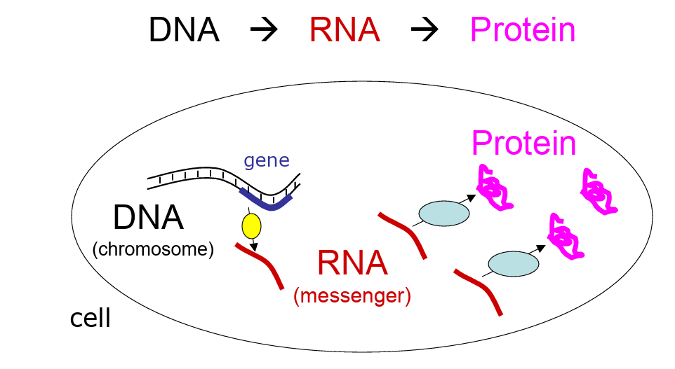

image

Various types of RNA:

- messenger RNA (mRNA)
- transfer RNA (tRNA)
- Ribosomal RNA (rRNA)
- micro RNA (miRNA)
- so on...

## Basics of RNA

- RNA is a basic biological molecule. It is **single stranded** (unlike the double helix of DNA).
- **DNA** has a fixed, stable double-helix structure — its shape is always the same.
- **RNA** folds back on itself, forming **base pairs** between complementary bases on the same strand. This folding produces a **secondary structure** — and this *structure varies* depending on the RNA sequence.
- The secondary structure of an RNA molecule often **governs its biological function** (e.g., ribozymes, tRNA cloverleaf, regulatory elements).
- **Goal:** Given an RNA sequence, predict its secondary structure — i.e., determine which bases pair up when it folds.

## Rules for RNA secondary structure formation

- Pairs of bases match up; each base matches with one other base.
- **A**denine always matches with **U**racil.
- **C**ytosine always matches with **G**uanine.
- There are no kinks in the folded molecule.
- Structures are knot-free.

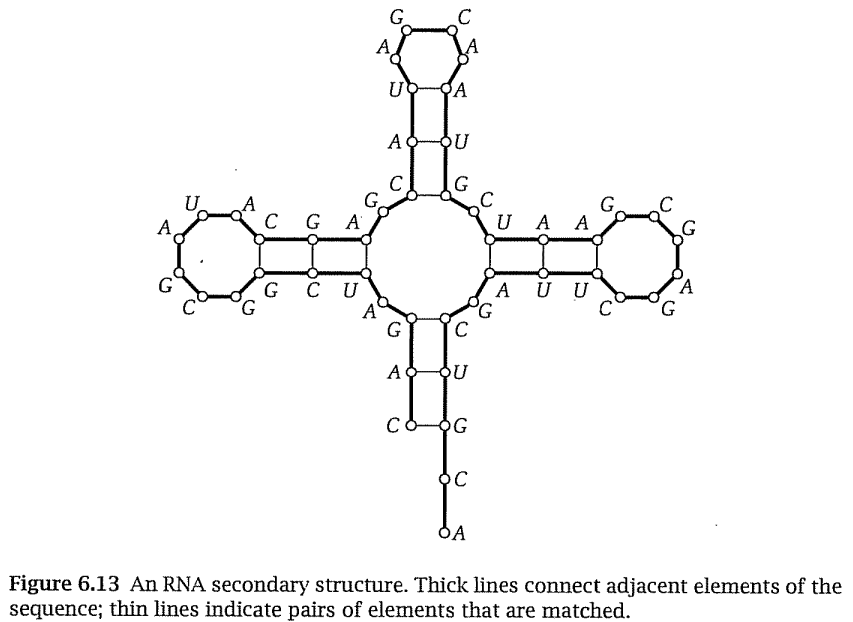

image

## Problem Formulation

Problem Given a single stranded RNA molecule, determine a secondary structure with the maximum possible number of base pairs.

**Notation:** A single stranded RNA molecule is a string $B = b_1b_2...b_n$ where each $b_i\in\{A, C, G, U\}$.

A secondary structure on $B$ is a set $S$ of pairs $(i, j)$ where $1\leq i, j\leq n$, following the rules below.

## Rules for a secondary structure formation

- **[No sharp turn]** The ends of each pair are separated by at least $4$ interleaving bases. i.e, if $(i,j)\in S$ then $i< j-4$.
- The elements of each base pair in $S$ consist of either $\{A, U\}$ or $\{G, C\}$ (in either order).
- $S$ is a matching: no base appears in more than one pair.
- **[No knots]** If $(i, j)$ and $(k, l)$ are two pairs in $S$, then we cannot have $i<k<j<l$.

## A different view of secondary structure

The energy of a secondary structure is proportional to the number of base pairs in it.

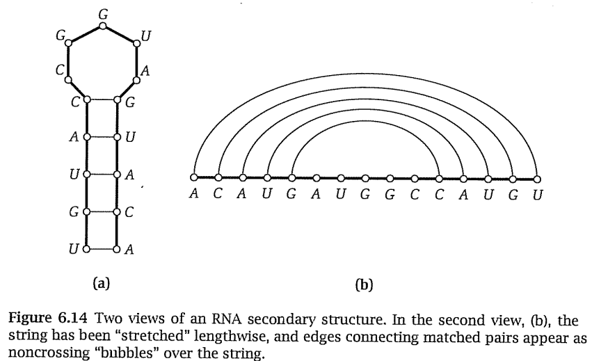

image

## Algorithm: Approach-1

1. Let $OPT(j)$ be the maximum number of base pairs in a secondary structure for $b_1b_2...b_j$. $OPT(j) = 0$, if $j\leq 5$.
2. In the optimal secondary structure on $b_1b_2...b_j$:
   - If $j$ is not a member of any pair, use $OPT(j-1)$.
   - If $j$ makes a pair with some $t< j-4$, knot condition yields two independent subproblems! One is $OPT(t-1)$, Other ??

## Visualization of the problem

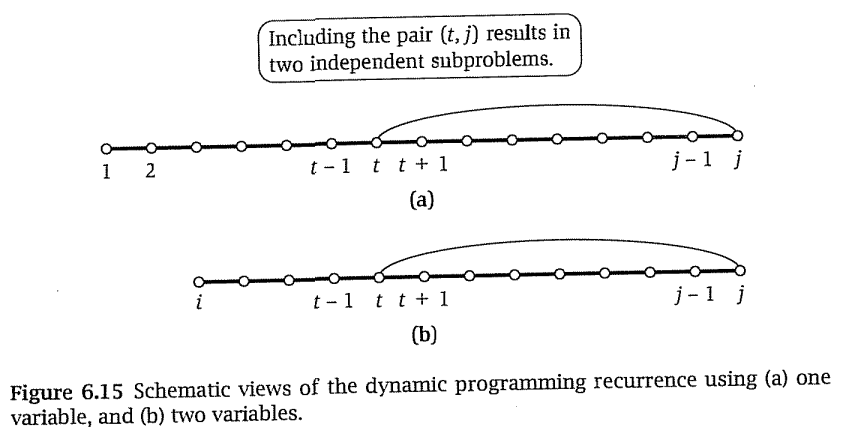

image

## Algorithm: Correct Approach

- Let $OPT(i,j)$ be the maximum number of base pairs in a secondary structure for $b_ib_{i+1}...b_j$. Clearly, $OPT(i,j) = 0$ if $i\geq j-4$.
- In the optimal secondary structure on $b_ib_{i+1}...b_j$:
  - If $j$ is not a member of any pair, use $OPT(i, j-1)$.
  - If $j$ pairs with some $t< j-4$, knot condition yields to independent subproblems! One is $OPT(i, t-1)$, and the other is $OPT(t+1, j-1)$.
- **Recurrence:**
  $$OPT(i,j) = \max\begin{cases}
  OPT(i, j-1) & \text{$j$ is unpaired},\\[4pt]
  \max\limits_{\substack{t < j-4 \\ (b_t,b_j)\text{ pairs}}} \big(OPT(i, t-1) + 1 + OPT(t+1, j-1)\big) & \text{$j$ pairs with $t$}
  \end{cases}$$

## Algorithm Complexity

- **Number of subproblems:** $O(n^2)$ — one for each pair $(i,j)$.
- **Work per subproblem:**
  - Either skip $j$ (constant time), or try all possible $t < j-4$ where $b_t$ pairs with $b_j$.
  - In the worst case, $O(n)$ per subproblem.
- **Total time:** $O(n^3)$.
- **Space:** $O(n^2)$ for the DP table.